# DAB501 Project 2

**Group Number:** 28  
**Group members and Student Number:**

1. Ibrahim Hussain (#0773950)
2. Manishpreet Kaur (#0784729)
3. Neha Neha (#0788774)
4. Vinny Sachdeva (#0755811)
5. Rakesh Singh (#0775942)

*We, Ibrahim Hussain, Manishpreet Kaur, Neha Neha, Vinny Sachdeva, and Rakesh Singh, hereby state that we have not communicated with or gained information in any way from any person or resource that would violate the College’s academic integrity policies, and that all work presented is our own. In addition, we also agree not to share our work in any way, before or after submission, that would violate the College’s academic integrity policies.*

**R Version:** Version 4.0.5  
**Rstudio Version:** Version 1.4.1103

# **Packages used:**

1. Tidyverse - 1.3.1
2. tidytuesdayR - 1.0.1

Load packages

```r
library(tidytuesdayR)
library(tidyverse)
transit_cost <- readr::read_csv('https://raw.githubusercontent.com/rfordatascience/tidytuesday/master/data/2021/2021-01-05/transit_cost.csv')
glimpse (transit_cost)
```

```
## Rows: 544
## Columns: 20
## $ e                <dbl> 7136, 7137, 7138, 7139, 7144, 7145, 7146, 7147, 7152,~
## $ country          <chr> "CA", "CA", "CA", "CA", "CA", "NL", "CA", "US", "US",~
## $ city             <chr> "Vancouver", "Toronto", "Toronto", "Toronto", "Toront~
## $ line             <chr> "Broadway", "Vaughan", "Scarborough", "Ontario", "Yon~
## $ start_year       <chr> "2020", "2009", "2020", "2020", "2020", "2003", "2020~
## $ end_year         <chr> "2025", "2017", "2030", "2030", "2030", "2018", "2026~
## $ rr               <dbl> 0, 0, 0, 0, 0, 0, 0, 0, 0, 0, 0, 0, 0, 0, 0, 0, 0, 0,~
## $ length           <dbl> 5.7, 8.6, 7.8, 15.5, 7.4, 9.7, 5.8, 5.1, 4.2, 4.2, 6.~
## $ tunnel_per       <chr> "87.72%", "100.00%", "100.00%", "57.00%", "100.00%", ~
## $ tunnel           <dbl> 5.0, 8.6, 7.8, 8.8, 7.4, 7.1, 5.8, 5.1, 4.2, 4.2, 6.3~
## $ stations         <dbl> 6, 6, 3, 15, 6, 8, 5, 2, 2, 2, 3, 3, 4, 7, 13, 4, 4, ~
## $ source1          <chr> "Plan", "Media", "Wiki", "Plan", "Plan", "Wiki", "Med~
## $ cost             <dbl> 2830, 3200, 5500, 8573, 5600, 3100, 4500, 1756, 3600,~
## $ currency         <chr> "CAD", "CAD", "CAD", "CAD", "CAD", "EUR", "CAD", "USD~
## $ year             <dbl> 2018, 2013, 2018, 2019, 2020, 2009, 2018, 2012, 2023,~
## $ ppp_rate         <dbl> 0.840, 0.810, 0.840, 0.840, 0.840, 1.300, 0.840, 1.00~
## $ real_cost        <chr> "2377.2", "2592", "4620", "7201.32", "4704", "4030", ~
## $ cost_km_millions <dbl> 417.05263, 301.39535, 592.30769, 464.60129, 635.67568~
## $ source2          <chr> "Media", "Media", "Media", "Plan", "Media", "Media", ~
## $ reference        <chr> "https://www.translink.ca/Plans-and-Projects/Rapid-Tr~
```

```r
view(transit_cost)
```

- Column e is not required as it does not carry any information.
- start_year and end_year are character which needs to be converted to integer.
- tunnel_per is character which needs to be converted to double after removing “%” from each rows.
- real cost is character which needs to be converted to double.

Removing column e and changing type of all the above mentioned columns.

```r
transit_cost <- transit_cost %>% select(-e)
```

```r
transit_cost <- transit_cost %>% mutate(tunnel_per = as.numeric(gsub("%", "", tunnel_per)), start_year = as.integer(start_year), end_year = as.integer(end_year))
transit_cost <- transit_cost %>% mutate(real_cost = as.double(real_cost))
transit_cost <- transit_cost[-c(538, 539, 540, 541, 542, 543, 544), ]
```

```r
view(transit_cost)
```

```r
head(transit_cost)
```

```
## # A tibble: 6 x 19
##   country city    line        start_year end_year    rr length tunnel_per tunnel
##   <chr>   <chr>   <chr>            <int>    <int> <dbl>  <dbl>      <dbl>  <dbl>
## 1 CA      Vancou~ Broadway          2020     2025     0    5.7       87.7    5
## 2 CA      Toronto Vaughan           2009     2017     0    8.6      100      8.6
## 3 CA      Toronto Scarborough       2020     2030     0    7.8      100      7.8
## 4 CA      Toronto Ontario           2020     2030     0   15.5       57      8.8
## 5 CA      Toronto Yonge to R~       2020     2030     0    7.4      100      7.4
## 6 NL      Amster~ North-South       2003     2018     0    9.7       73      7.1
## # ... with 10 more variables: stations <dbl>, source1 <chr>, cost <dbl>,
## #   currency <chr>, year <dbl>, ppp_rate <dbl>, real_cost <dbl>,
## #   cost_km_millions <dbl>, source2 <chr>, reference <chr>
```

```r
dim(transit_cost)
```

```
## [1] 537  19
```

```r
summary(transit_cost)
```

```
##    country              city               line             start_year
##  Length:537         Length:537         Length:537         Min.   :1982
##  Class :character   Class :character   Class :character   1st Qu.:2010
##  Mode  :character   Mode  :character   Mode  :character   Median :2015
##                                                           Mean   :2013
##                                                           3rd Qu.:2018
##                                                           Max.   :2025
##                                                           NA's   :60
##     end_year          rr              length         tunnel_per
##  Min.   :1987   Min.   :0.00000   Min.   :  0.60   Min.   :  0.00
##  1st Qu.:2016   1st Qu.:0.00000   1st Qu.:  6.50   1st Qu.: 50.75
##  Median :2020   Median :0.00000   Median : 15.70   Median :100.00
##  Mean   :2019   Mean   :0.06343   Mean   : 21.46   Mean   : 74.59
##  3rd Qu.:2023   3rd Qu.:0.00000   3rd Qu.: 28.85   3rd Qu.:100.00
##  Max.   :2030   Max.   :1.00000   Max.   :200.00   Max.   :100.00
##  NA's   :67     NA's   :1                          NA's   :25
##      tunnel          stations        source1               cost
##  Min.   :  0.00   Min.   :  0.00   Length:537         Min.   :       0
##  1st Qu.:  3.40   1st Qu.:  4.00   Class :character   1st Qu.:    2289
##  Median :  8.90   Median : 10.00   Mode  :character   Median :   11000
##  Mean   : 14.19   Mean   : 13.81                      Mean   :  805438
##  3rd Qu.: 21.45   3rd Qu.: 20.00                      3rd Qu.:   27000
##  Max.   :160.00   Max.   :128.00                      Max.   :90000000
##  NA's   :26       NA's   :8
##    currency              year         ppp_rate          real_cost
##  Length:537         Min.   :1987   Min.   :0.000064   Min.   :    0
##  Class :character   1st Qu.:2012   1st Qu.:0.237900   1st Qu.: 1208
##  Mode  :character   Median :2016   Median :0.258300   Median : 3037
##                     Mean   :2015   Mean   :0.660434   Mean   : 4437
##                     3rd Qu.:2019   3rd Qu.:1.000000   3rd Qu.: 5628
##                     Max.   :2027   Max.   :5.000000   Max.   :90000
##                                    NA's   :2
##  cost_km_millions    source2           reference
##  Min.   :   7.79   Length:537         Length:537
##  1st Qu.: 134.86   Class :character   Class :character
##  Median : 181.16   Mode  :character   Mode  :character
##  Mean   : 233.00
##  3rd Qu.: 240.76
##  Max.   :3928.57
##  NA's   :2
```

# *Univariate Analysis with one categorical variable*

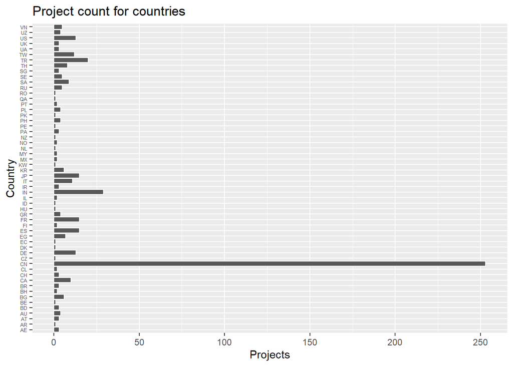

```r
transit_cost %>%
  drop_na(country) %>%
  ggplot()+
  geom_bar(mapping = aes(x = country), color = "white")+
  theme(axis.text.y = element_text(size = 5))+
  labs(title = "Project count for countries",
       y = "Projects",
       x = "Country")+
  coord_flip()
```

Using proportion in the above plot

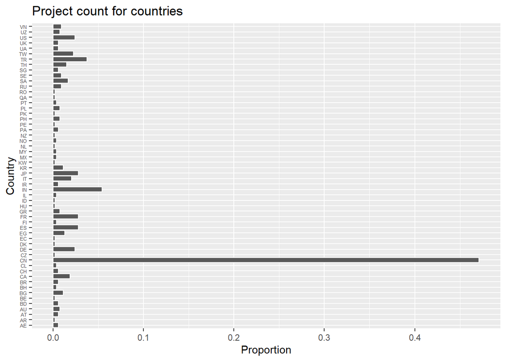

```r
transit_cost %>%
  drop_na(country) %>%
  ggplot()+
  geom_bar(mapping = aes(x = country, y = ..prop.., group = 1), color = "white")+
  theme(axis.text.y = element_text(size = 5))+
  labs(title = "Project count for countries",
       x = "Country",
       y = "Proportion")+
  coord_flip()
```

```r
country_count <- transit_cost %>%
  count(country) %>%
  slice_max(n = 10, n) %>%
  left_join(transit_cost, by = 'country')
view(country_count)
```

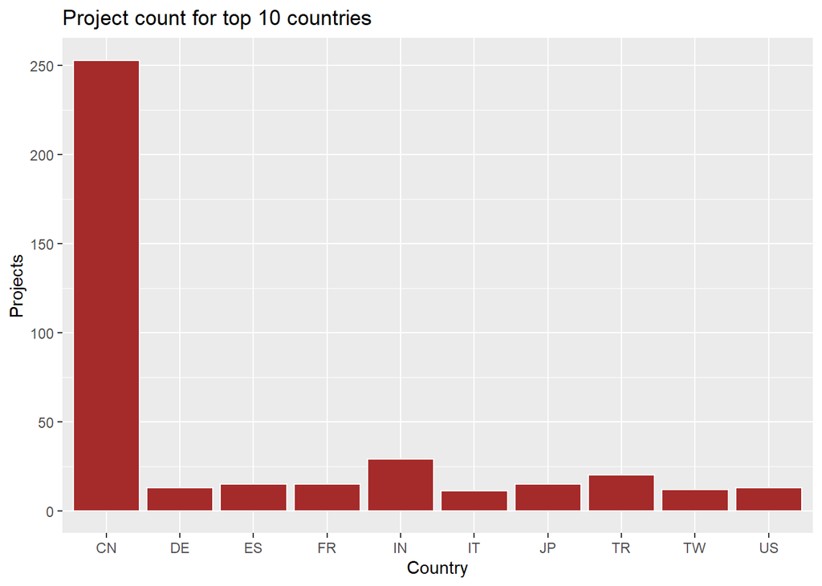

```r
country_count %>%
  drop_na(country) %>%
  ggplot()+
  geom_bar(mapping = aes(x = country), color = "white", fill = "brown")+
  labs(title = "Project count for top 10 countries",
       y = "Projects",
       x = "Country")
```

Above plot using proportion.

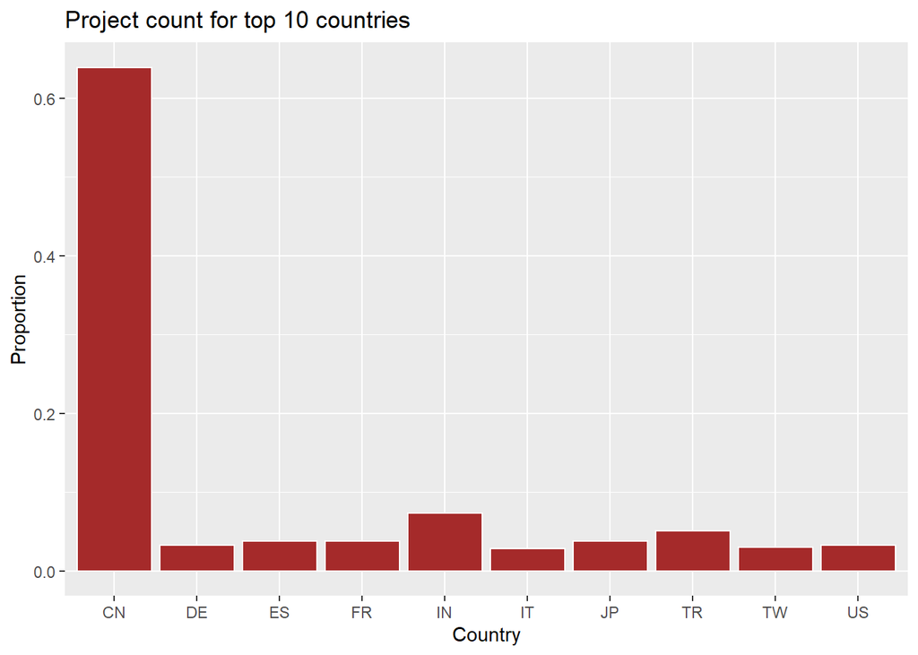

```r
country_count %>%
  drop_na(country) %>%
  ggplot()+
  geom_bar(mapping = aes(x = country, y = ..prop.., group = 1), color = "white", fill = "brown")+
  labs(title = "Project count for top 10 countries",
       x = "Country",
       y = "Proportion")
```

Above plot makes it very clear to observe project distribution of top 10 countries. Though India stands after China, but the difference between them is more than 200.  
There are very few unique values in this plot as only the top ten countries having majority of transit line projects were used.

```r
city_count <- transit_cost %>%
  count(city) %>%
  slice_max(n = 10, n) %>%
  left_join(transit_cost, by = 'city')
view(city_count)
```

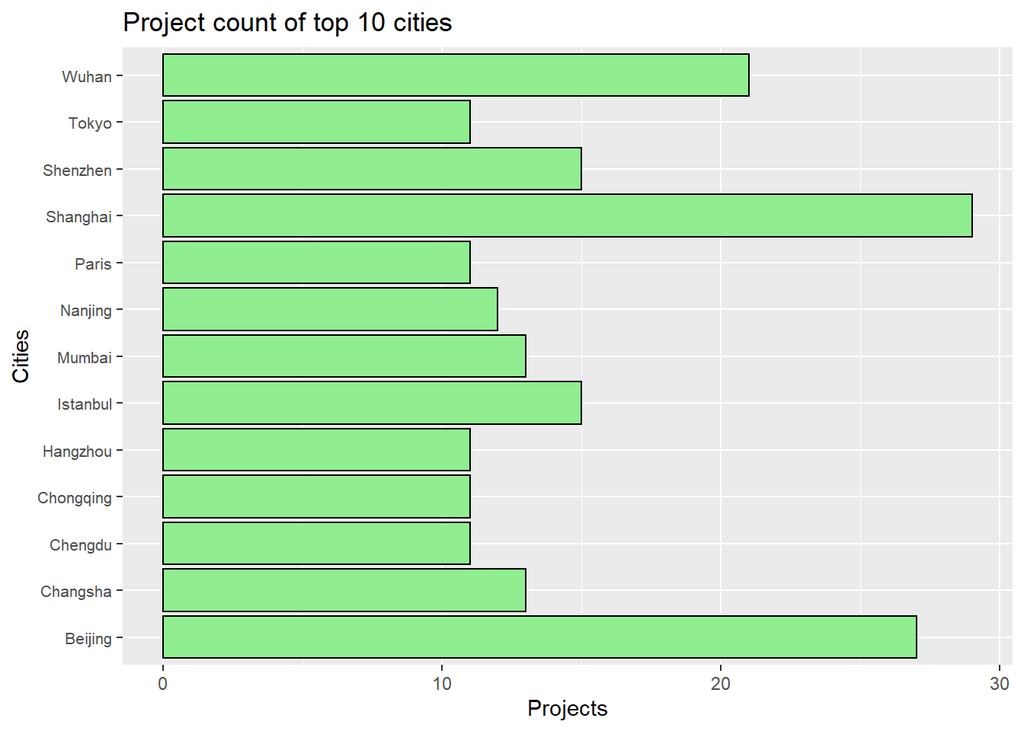

```r
city_count %>% drop_na(city) %>%
  ggplot()+
  geom_bar(aes(as.factor(city)), fill = "light green", color = "black")+
  theme(axis.text.y = element_text(size = 8))+
  labs(title = "Project count of top 10 cities",
       x = "Cities",
       y = "Projects")+
  coord_flip()
```

Proportion of above plot.

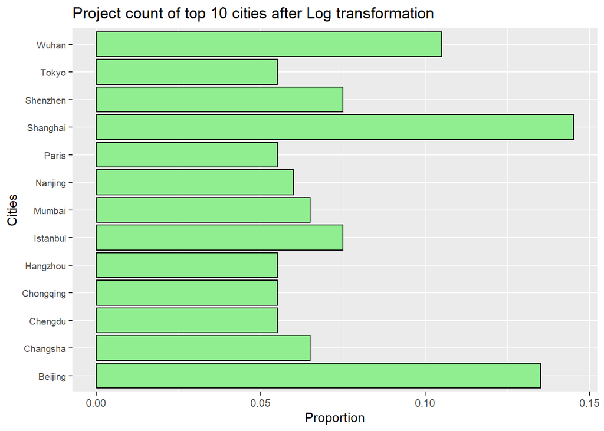

```r
city_count %>% drop_na(city) %>%
  ggplot()+
  geom_bar(aes(x = as.factor(city), y = ..prop.., group = 1), fill = "light green", color = "black", stat = "count")+
  theme(axis.text.y = element_text(size = 8))+
  labs(title = "Project count of top 10 cities after Log transformation",
       x = "Cities",
       y = "Proportion")+
  coord_flip()
```

China was working on most number of project in countries raised a curiosity about knowing which city tops in this list and which are the top 10 cities. The above plots tells that Shanghai had major number of projects with little less than 30 projects and right behind Shanghai was Beijing with around 25 projects. more than half of top 10 cities are from China remaining are from Japan, France, India, and Turkey.  
There are very few unique values in this plot as only the top ten cities having majority of transit line projects were used. And if all the cities were displayed in the plot then there would be too many unique values and visualization would have been very difficult.

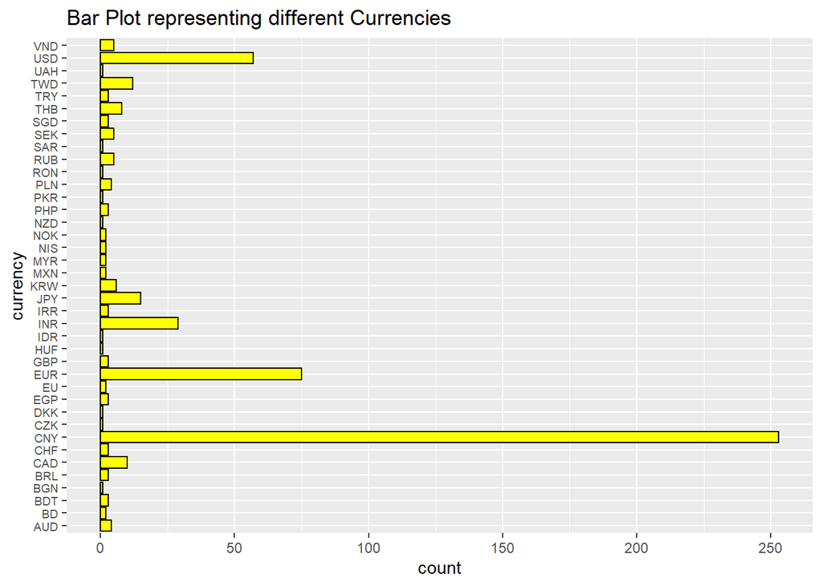

```r
transit_cost %>%
  drop_na(currency) %>%
  ggplot()+
  geom_bar(aes(currency),fill = "yellow",color = "black")+
  theme(axis.text.y = element_text(size = 7))+
  labs(title = "Bar Plot representing different Currencies")+
  coord_flip()
```

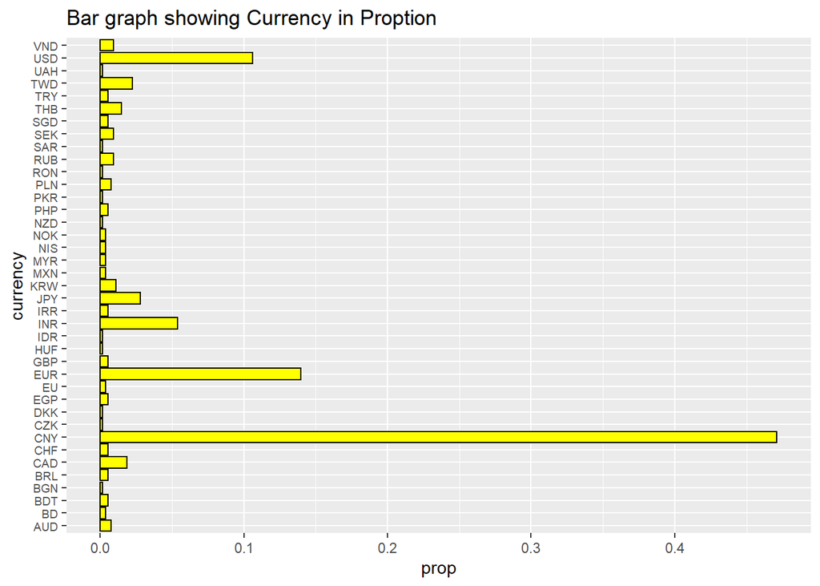

```r
transit_cost %>%
  drop_na(currency) %>%
  ggplot()+
  geom_bar(aes(x=currency,y=..prop..,group = 1),fill = "Yellow",color="black",stat = "count")+
  theme(axis.text.y = element_text(size = 7))+
  labs(title = "Bar graph showing Currency in Proption")+
  coord_flip()
```

As China was working on more transit line projects, it is not a shocker to see that Chinese Yen is the most used currency. Trailing behind Chinese Yen is Euro and USD. But when it comes to country ranking, India is at second place whereas Indian Rupee is at 4th place in currencies.  
Since currencies of all the countries are displayed in this plot, there are too many unique values which can cause confusion while visualizing.

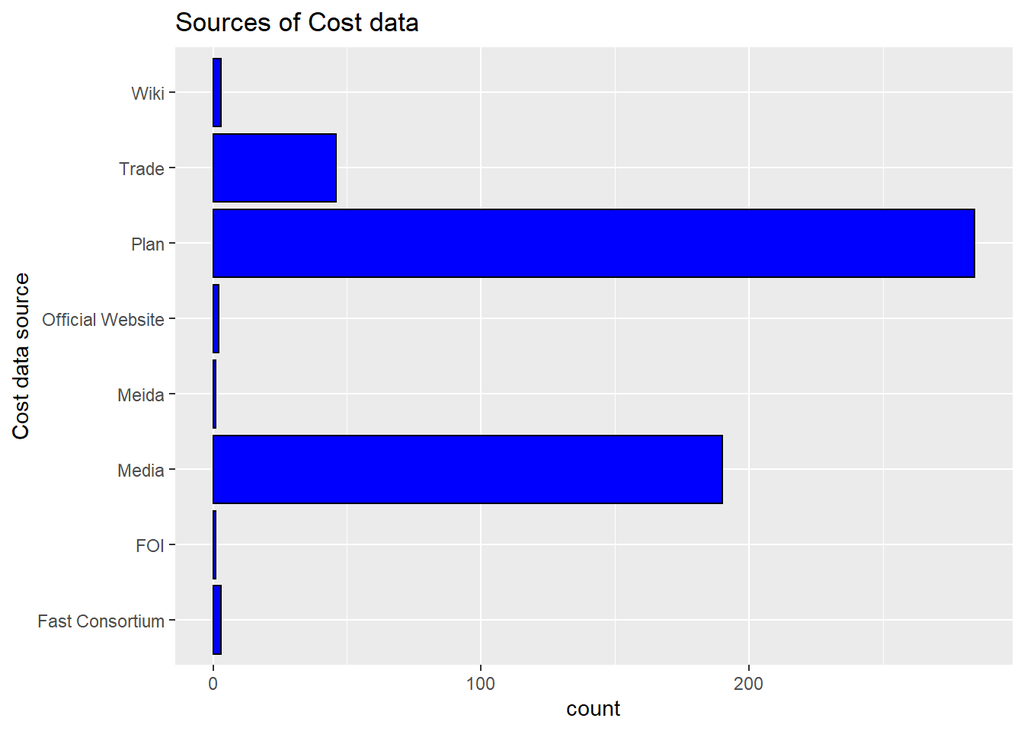

```r
transit_cost %>%
  drop_na(source2) %>%
  ggplot()+
  geom_bar(aes(x=source2),fill = "blue",color="black",stat = "count")+
  labs(title = "Sources of Cost data",
       x = "Cost data source")+
  coord_flip()
```

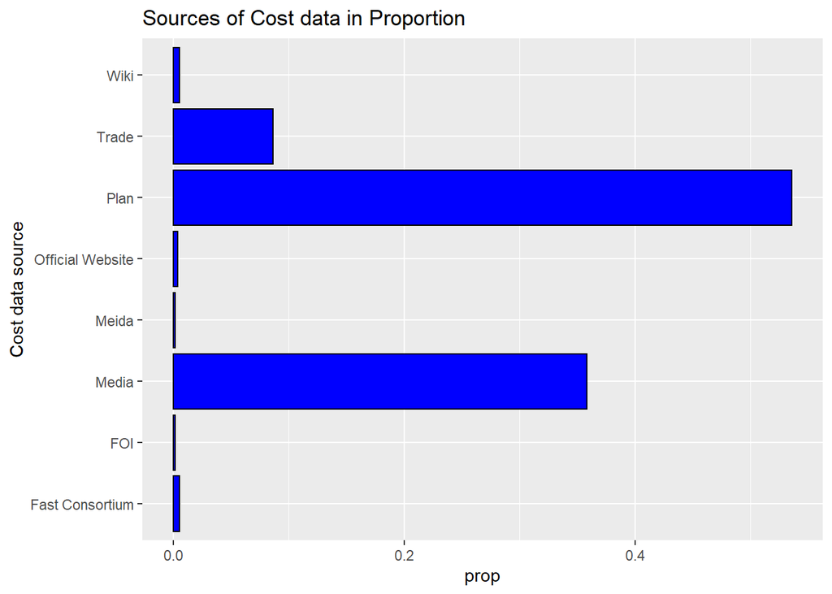

```r
transit_cost %>%
  drop_na(source2) %>%
  ggplot()+
  geom_bar(aes(x=source2,y=..prop..,group = 1),fill = "blue",color="black",stat = "count")+
  labs(title = "Sources of Cost data in Proportion",
       x = "Cost data source")+
  coord_flip()
```

From the Cost source plot it can be said that more than 280 data regarding cost of the project comes from project plans and around 180 from Media.  
There are appropriate amount of unique values in this plot, neither too many nor too few.

# *Univariate Analysis with one numeric variable*

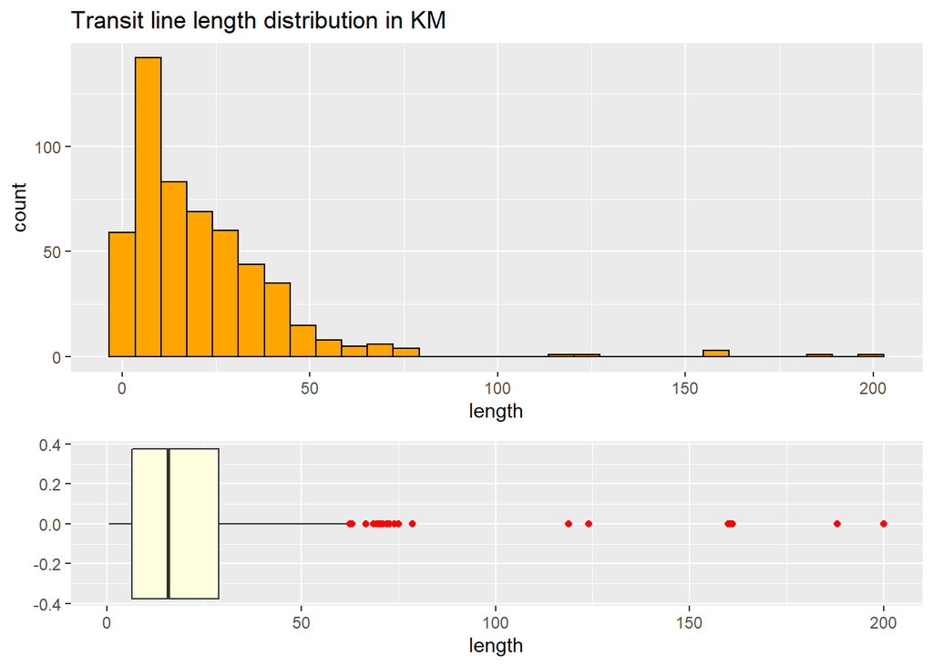

```r
plt1 <- ggplot(transit_cost)+
  geom_histogram(aes(length), fill = "orange", color = "black")+
  labs(title = "Transit line length distribution in KM")

plt2 <- ggplot(transit_cost)+
  geom_boxplot(aes(length), outlier.color = "red", fill = "light yellow")

egg::ggarrange(plt1, plt2, heights = 2:1)
```

**Median**

```r
median(transit_cost$length, na.rm = TRUE)
```

```
## [1] 15.7
```

**IQR**

```r
IQR(transit_cost$length, na.rm = TRUE)
```

```
## [1] 22.35
```

Transit line length distribution plot displayed above indicates that a large number of projects total length falls under 20km.  
According to the box plot all the values after 60 can be called as **outliers**, but they will not be considered as noise as it is very normal for some transits to be of more length compared with other transits.  
Above distribution is **Right skewed** and **Unimodal**. Since it is skewed, for clear visualization of the data it is better to do a log transformation, which is displayed in below plot.  
Central tendency of this distribution will be **Median** which is equal to 15.7 and spread will be **IQR** i.e. 22.35, as it is often more helpful for skewed distribution to use Median and IQR as central tendency and measure of spread.

**Log Transformation**

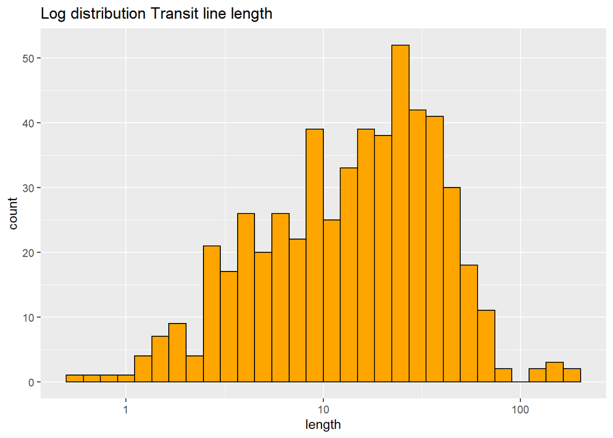

```r
ggplot(transit_cost)+
  geom_histogram(aes(length), fill = "orange", color = "black")+
  labs(title = "Log distribution Transit line length ")+
  scale_x_log10()
```

This distribution shape is close to bell curve and hence it is more easy to visualize.

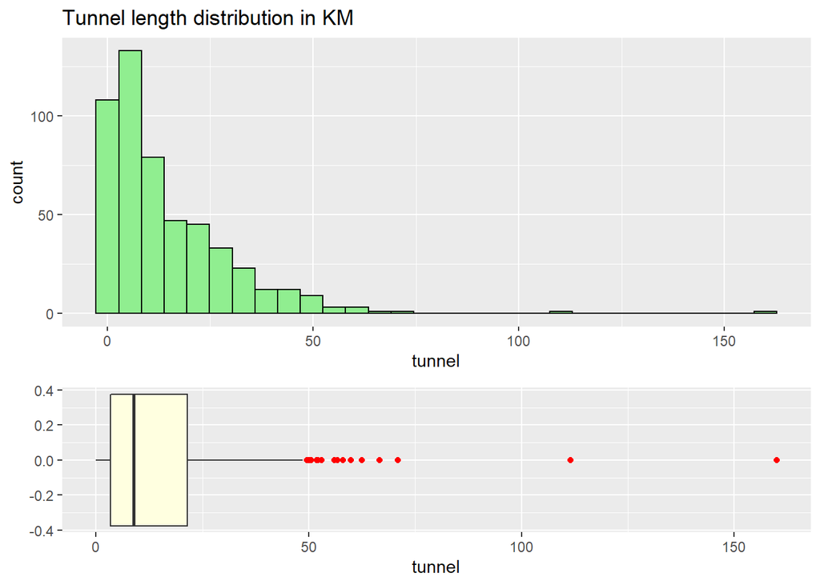

```r
plt3 <- ggplot(transit_cost)+
  geom_histogram(aes(tunnel), fill = "Light green", color = "black")+
  labs(title = "Tunnel length distribution in KM")

plt4 <- ggplot(transit_cost)+
  geom_boxplot(aes(tunnel), outlier.color = "red", fill = "light yellow")

egg::ggarrange(plt3, plt4, heights = 2:1)
```

**Median**

```r
median(transit_cost$tunnel, na.rm = TRUE)
```

```
## [1] 8.9
```

**IQR**

```r
IQR(transit_cost$tunnel, na.rm = TRUE)
```

```
## [1] 18.05
```

**Log Transformation**

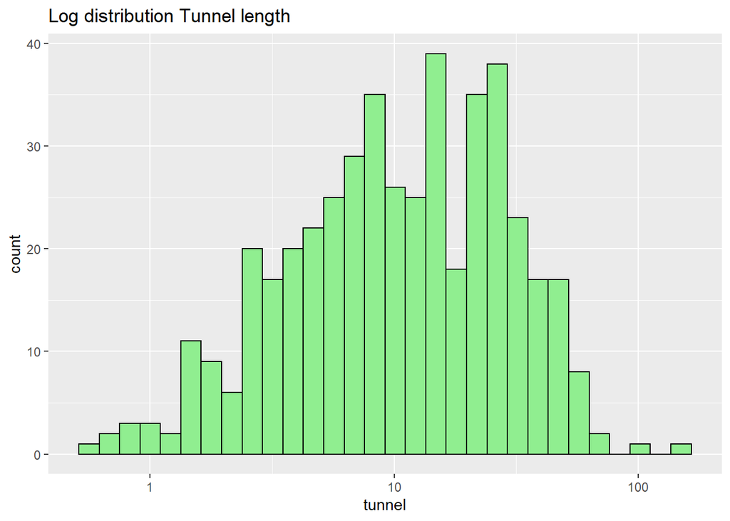

```r
ggplot(transit_cost)+
  geom_histogram(aes(tunnel), fill = "Light green", color = "black")+
  labs(title = "Log distribution Tunnel length")+
  scale_x_log10()
```

This distribution shape of Tunnel length is closer to bell curve shape and hence it is more easy to visualize.

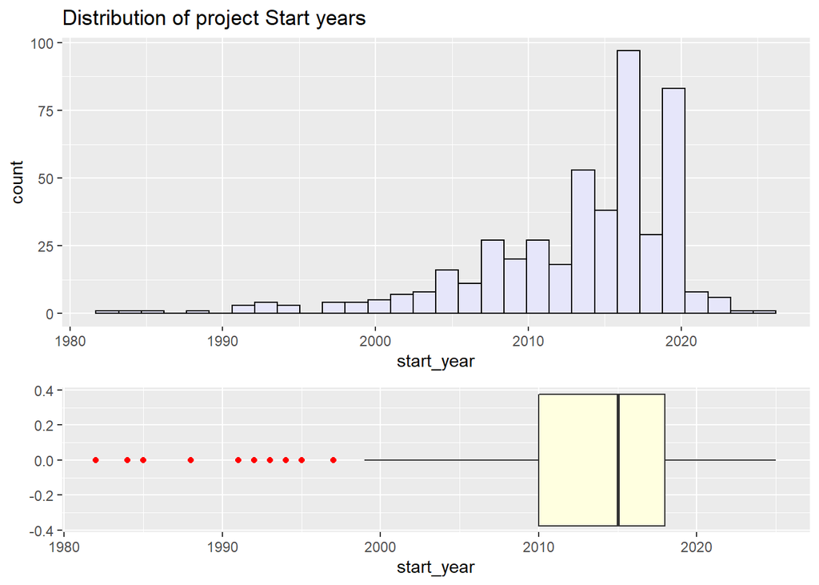

```r
plt5 <- ggplot(transit_cost)+
  geom_histogram(aes(start_year), fill = "lavender", color = "black")+
  labs(title = "Distribution of project Start years")

plt6 <- ggplot(transit_cost)+
  geom_boxplot(aes(start_year), outlier.color = "red", fill = "light yellow")

egg::ggarrange(plt5, plt6, heights = 2:1)
```

**Median**

```r
median(transit_cost$start_year, na.rm = TRUE)
```

```
## [1] 2015
```

**IQR**

```r
IQR(transit_cost$start_year, na.rm = TRUE)
```

```
## [1] 8
```

**Log Transformation**

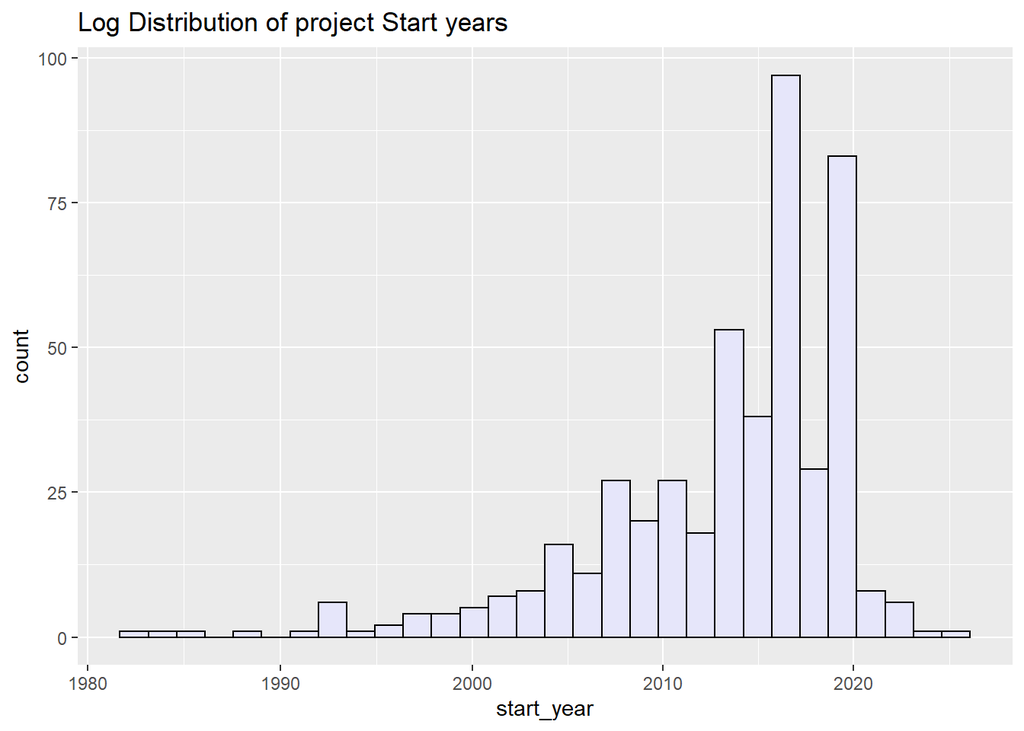

```r
ggplot(transit_cost)+
  geom_histogram(aes(start_year), fill = "lavender", color = "black")+
  labs(title = "Log Distribution of project Start years")+
  scale_x_log10()
```

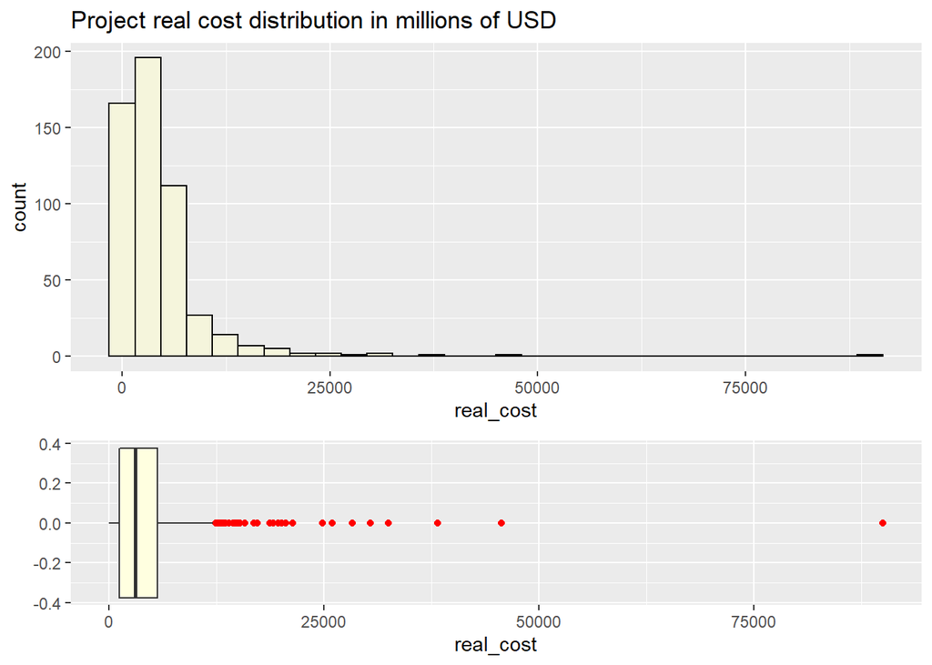

```r
plt7 <- ggplot(transit_cost)+
  geom_histogram(aes(real_cost), fill = "Beige", color = "black")+
  labs(title = "Project real cost distribution in millions of USD")

plt8 <- ggplot(transit_cost)+
  geom_boxplot(aes(real_cost), outlier.color = "red", fill = "light yellow")

egg::ggarrange(plt7, plt8, heights = 2:1)
```

**Median**

```r
median(transit_cost$real_cost, na.rm = TRUE)
```

```
## [1] 3037.16
```

**IQR**

```r
IQR(transit_cost$real_cost, na.rm = TRUE)
```

```
## [1] 4420.27
```

Even though most of the projects expenditure were done in local currencies, but knowing the expenditure on a project in one same currency will make it very easy to understand the trend. And USD being the worldwide recognized and most used currency will be best in this case and above plot shows the distribution on construction cost in USD. Majority of the project expenditure can be said to be well under 12000 million USD, but there is one project on which more than 75000 million USD were spend.  
According to the box plot all the values after 12000 million USD can be called as **outliers**, reason for more spending can be anything from good or bad and hence, to get clear idea of the trend of expenditure worldwide it is better to not take the outliers into consideration.  
Above distribution is **Right skewed** and **Unimodal**. Since it is skewed, for clear visualization of the data it is better to do a log transformation, which is displayed in below plot.  
Central tendency of this distribution will be **Median** which is equal to 3037.16 and spread will be **IQR** i.e. 4420.27, as it is often more helpful for skewed distribution to use Median and IQR as central tendency and measure of spread.